# problem set 10

3032247297

I collaborated with nobody on this assignment.

Question A

```r
RK <- read.table("RoadKills.txt", header = TRUE)
summary(RK)
```

```
##      Sector            X                Y           BufoCalamita
##  Min.   : 1.00   Min.   :258260   Min.   :231911   Min.   : 0.000
##  1st Qu.:13.75   1st Qu.:258668   1st Qu.:238007   1st Qu.: 0.000
##  Median :26.50   Median :259120   Median :244162   Median : 3.000
##  Mean   :26.50   Mean   :259241   Mean   :244211   Mean   : 8.135
##  3rd Qu.:39.25   3rd Qu.:259935   3rd Qu.:250496   3rd Qu.: 8.250
##  Max.   :52.00   Max.   :260370   Max.   :256546   Max.   :67.000
##      TOT.N            S.RICH          OPEN.L           OLIVE
##  Min.   :  2.00   Min.   :1.000   Min.   : 0.738   Min.   : 0.000
##  1st Qu.:  7.00   1st Qu.:3.000   1st Qu.:15.702   1st Qu.: 0.000
##  Median : 17.50   Median :5.000   Median :28.533   Median : 0.674
##  Mean   : 25.90   Mean   :4.692   Mean   :36.175   Mean   : 7.350
##  3rd Qu.: 34.25   3rd Qu.:6.000   3rd Qu.:51.765   3rd Qu.: 8.474
##  Max.   :104.00   Max.   :8.000   Max.   :97.574   Max.   :60.333
##      MONT.S           MONT           POLIC             SHRUB
##  Min.   :0.000   Min.   : 0.00   Min.   : 0.0000   Min.   :0.00000
##  1st Qu.:0.000   1st Qu.:25.05   1st Qu.: 0.0000   1st Qu.:0.02975
##  Median :0.000   Median :44.23   Median : 0.0600   Median :0.09300
##  Mean   :1.077   Mean   :48.12   Mean   : 0.6025   Mean   :0.22881
##  3rd Qu.:1.175   3rd Qu.:75.40   3rd Qu.: 0.3257   3rd Qu.:0.20950
##  Max.   :9.426   Max.   :95.08   Max.   :11.2630   Max.   :1.74400
##      URBAN           WAT.RES          L.WAT.C          L.D.ROAD
##  Min.   : 0.000   Min.   :0.0000   Min.   :0.0000   Min.   : 105.3
##  1st Qu.: 0.000   1st Qu.:0.0000   1st Qu.:0.8135   1st Qu.:1062.1
##  Median : 0.195   Median :0.0425   Median :1.5500   Median :2098.0
##  Mean   : 2.771   Mean   :0.3213   Mean   :1.5617   Mean   :2119.1
##  3rd Qu.: 1.551   3rd Qu.:0.2135   3rd Qu.:2.1990   3rd Qu.:2983.8
##  Max.   :28.086   Max.   :6.3090   Max.   :3.9510   Max.   :4891.5
##     L.P.ROAD        D.WAT.RES         D.WAT.COUR          D.PARK
##  Min.   :0.5710   Min.   :  59.17   Min.   :  15.18   Min.   :  250.2
##  1st Qu.:0.6450   1st Qu.: 381.91   1st Qu.:  91.58   1st Qu.: 6573.4
##  Median :0.6810   Median : 674.61   Median : 196.01   Median :12719.6
##  Mean   :0.9645   Mean   : 703.52   Mean   : 288.68   Mean   :12680.9
##  3rd Qu.:1.1818   3rd Qu.: 958.20   3rd Qu.: 359.58   3rd Qu.:18780.1
##  Max.   :2.9600   Max.   :1883.00   Max.   :1165.00   Max.   :24884.8
##     N.PATCH           P.EDGE          L.SDI
##  Min.   : 15.00   Min.   :125.2   Min.   :1.124
##  1st Qu.: 19.00   1st Qu.:197.8   1st Qu.:1.423
##  Median : 28.00   Median :257.4   Median :1.602
##  Mean   : 34.40   Mean   :289.1   Mean   :1.595
##  3rd Qu.: 40.25   3rd Qu.:377.6   3rd Qu.:1.800
##  Max.   :122.00   Max.   :553.9   Max.   :1.963
```

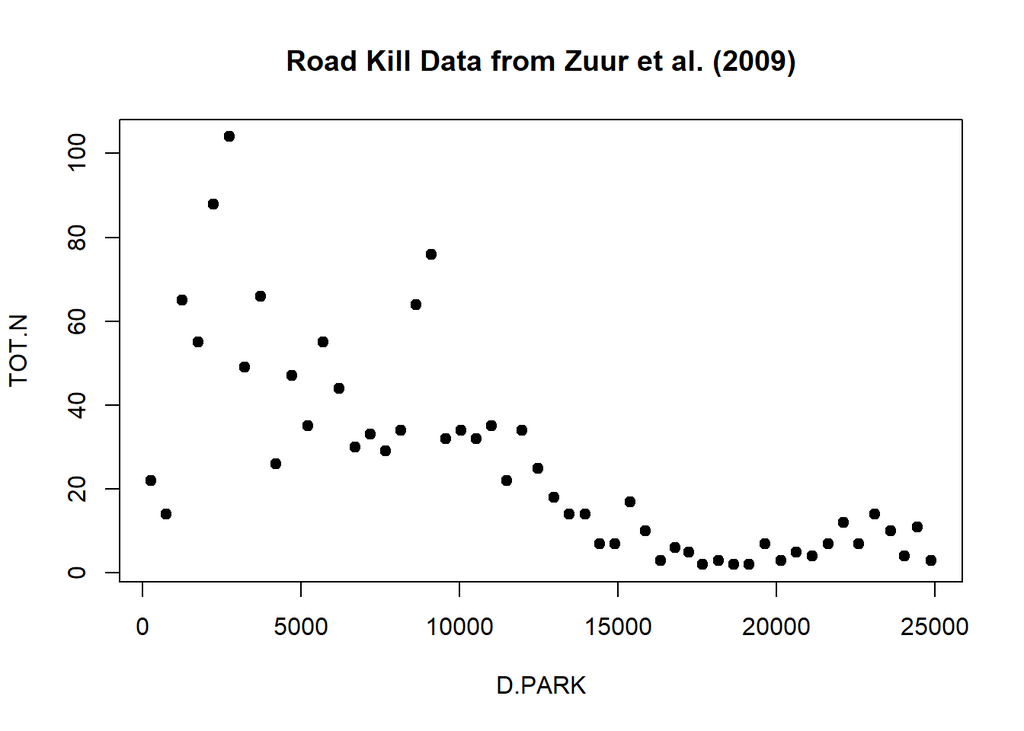

```r
with(RK, plot(D.PARK, TOT.N, pch = 19, main = "Road Kill Data from Zuur et al. (2009)"))
```

Question B

```r
fit1 <- glm(TOT.N ~ D.PARK, family = poisson, data = RK)
summary(fit1)
```

```
##
## Call:
## glm(formula = TOT.N ~ D.PARK, family = poisson, data = RK)
##
## Deviance Residuals:
##     Min       1Q   Median       3Q      Max
## -8.1100  -1.6950  -0.4708   1.4206   7.3337
##
## Coefficients:
##               Estimate Std. Error z value Pr(>|z|)
## (Intercept)  4.316e+00  4.322e-02   99.87   <2e-16 ***
## D.PARK      -1.059e-04  4.387e-06  -24.13   <2e-16 ***
## ---
## Signif. codes:  0 '***' 0.001 '**' 0.01 '*' 0.05 '.' 0.1 ' ' 1
##
## (Dispersion parameter for poisson family taken to be 1)
##
##     Null deviance: 1071.4  on 51  degrees of freedom
## Residual deviance:  390.9  on 50  degrees of freedom
## AIC: 634.29
##
## Number of Fisher Scoring iterations: 4
```

```r
logLik(fit1)
```

```
## 'log Lik.' -315.1434 (df=2)
```

```r
AIC(fit1)
```

```
## [1] 634.2868
```

```r
deviance(fit1)
```

```
## [1] 390.8969
```

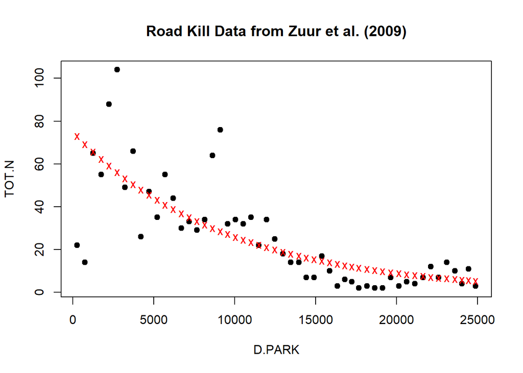

```r
{
  with(RK, plot(D.PARK, TOT.N, pch = 19, main = "Road Kill Data from Zuur et al. (2009)"))
  with(RK, points(D.PARK, fitted(fit1), pch = 'x', col = 'red'))
}
```

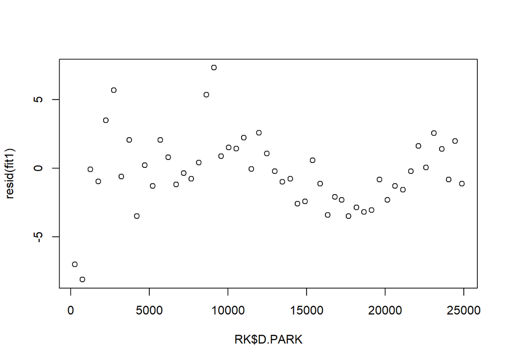

```r
plot(RK$D.PARK, resid(fit1))
```

Question C

I think the first violation is that the errors are not independent, and the second is that the data does not seem to have constant variance. As X increases, the data gets clustered closer and closer together which indicates a decrease in variance and std deviation.It also does not look like there is a linear relationship between the response and the linear predictor, it seems almost sinusoidal, this is another violation of the GLM assumption.

Question D

```r
RK$D.PARK[15]
```

```
## [1] 7187.762
```

```r
RK$TOT.N[15]
```

```
## [1] 33
```

```r
RK
```

| Sector | X | Y | BufoCalamita | TOT.N | S.RICH | OPEN.L | OLIVE | MONT.S | MONT | POLIC | SHRUB | URBAN | WAT.RES | L.WAT.C | L.D.ROAD | L.P.ROAD | D.WAT.RES | D.WAT.COUR | D.PARK | N.PATCH | P.EDGE | L.SDI |
| --- | --- | --- | --- | --- | --- | --- | --- | --- | --- | --- | --- | --- | --- | --- | --- | --- | --- | --- | --- | --- | --- | --- |
| 1 | 260181 | 256546 | 5 | 22 | 3 | 22.684 | 60.333 | 0.000 | 0.653 | 4.811 | 0.406 | 7.787 | 0.043 | 0.583 | 3330.189 | 1.975 | 252.113 | 735.000 | 250.214 | 122 | 553.936 | 1.801 |
| 2 | 259914 | 256124 | 1 | 14 | 4 | 24.657 | 40.832 | 0.000 | 0.161 | 2.224 | 0.735 | 27.150 | 0.182 | 1.419 | 2587.498 | 1.761 | 139.573 | 134.052 | 741.179 | 96 | 457.142 | 1.886 |
| 3 | 259672 | 255688 | 40 | 65 | 6 | 30.121 | 23.710 | 0.258 | 10.918 | 1.946 | 0.474 | 28.086 | 0.453 | 2.005 | 2149.651 | 1.250 | 59.168 | 269.029 | 1240.080 | 67 | 432.360 | 1.930 |
| 4 | 259454 | 255238 | 27 | 55 | 5 | 50.277 | 14.940 | 1.783 | 26.454 | 0.625 | 0.607 | 0.831 | 0.026 | 1.924 | 4222.983 | 0.666 | 277.842 | 48.751 | 1739.885 | 63 | 421.292 | 1.865 |
| 5 | 259307 | 254763 | 67 | 88 | 4 | 43.609 | 35.353 | 2.431 | 11.330 | 0.791 | 0.173 | 2.452 | 0.000 | 2.167 | 2219.302 | 0.653 | 967.808 | 126.102 | 2232.130 | 59 | 407.573 | 1.818 |
| 6 | 259189 | 254277 | 56 | 104 | 7 | 31.385 | 17.666 | 0.000 | 43.678 | 0.054 | 0.325 | 2.730 | 0.039 | 2.391 | 1005.629 | 1.309 | 560.000 | 344.444 | 2724.089 | 49 | 420.289 | 1.799 |
| 7 | 259092 | 253786 | 27 | 49 | 7 | 24.810 | 9.786 | 0.000 | 60.660 | 0.022 | 0.055 | 1.001 | 0.114 | 1.165 | 3735.189 | 0.685 | 93.147 | 95.133 | 3215.511 | 35 | 298.617 | 1.593 |
| 8 | 258993 | 253296 | 37 | 66 | 7 | 56.228 | 1.619 | 0.000 | 25.280 | 11.263 | 0.092 | 0.083 | 0.224 | 2.428 | 4891.466 | 0.677 | 88.971 | 243.230 | 3709.401 | 55 | 442.750 | 1.627 |
| 9 | 258880 | 252809 | 8 | 26 | 7 | 48.735 | 0.603 | 1.108 | 41.722 | 1.238 | 1.744 | 0.185 | 0.177 | 2.416 | 4010.961 | 0.664 | 684.887 | 187.084 | 4206.477 | 52 | 431.084 | 1.801 |
| 10 | 258767 | 252322 | 16 | 47 | 6 | 15.633 | 0.000 | 0.000 | 82.069 | 0.119 | 0.000 | 0.361 | 0.000 | 0.211 | 2885.246 | 0.654 | 794.000 | 236.004 | 4704.176 | 26 | 220.231 | 1.440 |

[output cut: 42 more lines]

1. 15(7187.762) + 33 = 107,849
2. 4.316 - 15(.000106) = 4.314

```r
summary(RK[15])
```

```
##     L.WAT.C
##  Min.   :0.0000
##  1st Qu.:0.8135
##  Median :1.5500
##  Mean   :1.5617
##  3rd Qu.:2.1990
##  Max.   :3.9510
```

```r
u <- 1.5617

exp(-u)*(u^4.314)/factorial(4.314)
```

```
## [1] 0.03687325
```

The answer is .0369

Question E

```r
logLikelihood <- function(intercept, slope) {
  sum(dpois(RK$TOT.N, exp(intercept + slope*RK$D.PARK), log = TRUE))
}
logLikelihood(4.316e+00, -1.059e-04)
```

```
## [1] -315.144
```

```r
slope.grid <- -0.000106 + seq(-9e-6, 9e-6, length = 21)
cbind(slope.grid) ## cbind shows the values vertically, which is easier to read.
```

```
##       slope.grid
##  [1,] -0.0001150
##  [2,] -0.0001141
##  [3,] -0.0001132
##  [4,] -0.0001123
##  [5,] -0.0001114
##  [6,] -0.0001105
##  [7,] -0.0001096
##  [8,] -0.0001087
##  [9,] -0.0001078
## [10,] -0.0001069
## [11,] -0.0001060
## [12,] -0.0001051
## [13,] -0.0001042
## [14,] -0.0001033
## [15,] -0.0001024
## [16,] -0.0001015
## [17,] -0.0001006
## [18,] -0.0000997
## [19,] -0.0000988
## [20,] -0.0000979
## [21,] -0.0000970
```

```r
intercept.grid <- 4.32 + seq(-9e-2, 9e-2, length = 21)
cbind(intercept.grid)
```

```
##       intercept.grid
##  [1,]          4.230
##  [2,]          4.239
##  [3,]          4.248
##  [4,]          4.257
##  [5,]          4.266
##  [6,]          4.275
##  [7,]          4.284
##  [8,]          4.293
##  [9,]          4.302
## [10,]          4.311
## [11,]          4.320
## [12,]          4.329
## [13,]          4.338
## [14,]          4.347
## [15,]          4.356
## [16,]          4.365
## [17,]          4.374
## [18,]          4.383
## [19,]          4.392
## [20,]          4.401
## [21,]          4.410
```

```r
z <- matrix(0, nrow = length(intercept.grid), ncol = length(slope.grid))
for(i in 1:length(intercept.grid))
  for(j in 1:length(slope.grid))
    z[i, j] <- logLikelihood(intercept.grid[i], slope.grid[j])
z
```

```
##            [,1]      [,2]      [,3]      [,4]      [,5]      [,6]
##  [1,] -332.6323 -330.9871 -329.4272 -327.9538 -326.5682 -325.2715
##  [2,] -330.9399 -329.3636 -327.8734 -326.4705 -325.1562 -323.9316
##  [3,] -329.3417 -327.8351 -326.4152 -325.0835 -323.8410 -322.6892
##  [4,] -327.8388 -326.4023 -325.0534 -323.7934 -322.6236 -321.5451
##  [5,] -326.4318 -325.0662 -323.7889 -322.6014 -321.5047 -320.5003
##  [6,] -325.1217 -323.8275 -322.6226 -321.5081 -320.4854 -319.5557
##  [7,] -323.9094 -322.6873 -321.5553 -320.5145 -319.5664 -318.7121
##  [8,] -322.7957 -321.6464 -320.5880 -319.6216 -318.7487 -317.9705
##  [9,] -321.7816 -320.7057 -319.7215 -318.8302 -318.0332 -317.3318
## [10,] -320.8679 -319.8661 -318.9568 -318.1413 -317.4209 -316.7970
## [11,] -320.0555 -319.1284 -318.2947 -317.5557 -316.9126 -316.3669
## [12,] -319.3453 -318.4937 -317.7363 -317.0744 -316.5093 -316.0424
## [13,] -318.7384 -317.9629 -317.2824 -316.6983 -316.2120 -315.8247
## [14,] -318.2356 -317.5369 -316.9341 -316.4285 -316.0216 -315.7146
```

[output cut: 73 more lines]

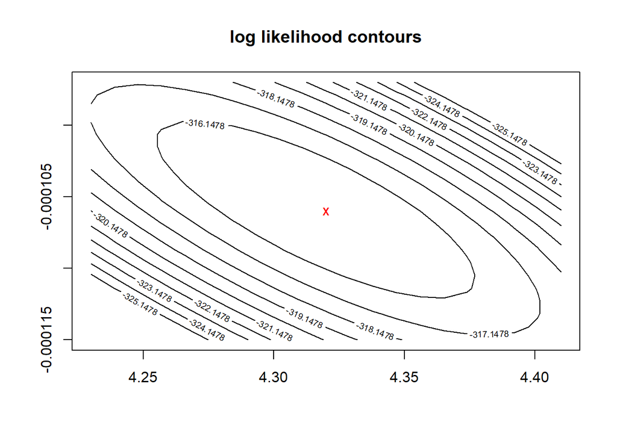

```r
{
  contour(intercept.grid, slope.grid, z,
          levels = max(z) - (1:10), main = "log likelihood contours")
  points(4.32, -0.000106, pch = 'x', col = 'red')
}
```

The log likelihood surface looks like tree rings comprised of ellipses.

```r
fit2 <- glm(TOT.N ~ D.PARK, family = quasipoisson, data = RK)
summary(fit2)
```

[output not shown]

Question F

The reported dispersion parameter is 7.630

Question G

The parameter estimates are nearly the same while the standard error is bigger and the resulting confidence intervals are also larger. The p value for Dpark is also less significant in fit2 than in fit1 but still very significant.

```r
logLik(fit2)
```

```
## 'log Lik.' NA (df=2)
```

```r
AIC(fit2)
```

```
## [1] NA
```

```r
deviance(fit2)
```

```
## [1] 390.8969
```

Question H

The deviance is the same in fit2 as fit1.

```r
RK$SQ.POLIC<-sqrt(RK$POLIC)
RK$SQ.WATRES<-sqrt(RK$WAT.RES)
RK$SQ.URBAN<-sqrt(RK$URBAN)
RK$SQ.OLIVE<-sqrt(RK$OLIVE)
RK$SQ.LPROAD<-sqrt(RK$L.P.ROAD)
RK$SQ.SHRUB<-sqrt(RK$SHRUB)
RK$SQ.DWATCOUR<-sqrt(RK$D.WAT.COUR)
fit3<-glm(TOT.N ~
            OPEN.L +
            MONT.S +
            SQ.POLIC +
            SQ.SHRUB +
            SQ.WATRES +
            L.WAT.C +
            SQ.LPROAD +
            SQ.DWATCOUR +
            D.PARK,
          family=poisson,
          data=RK)
summary(fit3)
```

```
##
## Call:
## glm(formula = TOT.N ~ OPEN.L + MONT.S + SQ.POLIC + SQ.SHRUB +
##     SQ.WATRES + L.WAT.C + SQ.LPROAD + SQ.DWATCOUR + D.PARK, family = poisson,
##     data = RK)
##
## Deviance Residuals:
##     Min       1Q   Median       3Q      Max
## -6.8398  -1.3965  -0.1409   1.4641   4.3749
##
## Coefficients:
##               Estimate Std. Error z value Pr(>|z|)
## (Intercept)  3.749e+00  1.567e-01  23.935  < 2e-16 ***
## OPEN.L      -3.025e-03  1.580e-03  -1.915 0.055531 .
## MONT.S       8.697e-02  1.359e-02   6.398 1.57e-10 ***
## SQ.POLIC    -1.787e-01  4.676e-02  -3.822 0.000133 ***
## SQ.SHRUB    -6.112e-01  1.176e-01  -5.197 2.02e-07 ***
## SQ.WATRES    2.243e-01  7.050e-02   3.181 0.001468 **
## L.WAT.C      3.355e-01  4.127e-02   8.128 4.36e-16 ***
## SQ.LPROAD    4.517e-01  1.348e-01   3.351 0.000804 ***
## SQ.DWATCOUR  7.355e-03  4.879e-03   1.508 0.131629
## D.PARK      -1.301e-04  5.936e-06 -21.923  < 2e-16 ***
## ---
## Signif. codes:  0 '***' 0.001 '**' 0.01 '*' 0.05 '.' 0.1 ' ' 1
##
## (Dispersion parameter for poisson family taken to be 1)
##
##     Null deviance: 1071.44  on 51  degrees of freedom
## Residual deviance:  270.23  on 42  degrees of freedom
## AIC: 529.62
##
## Number of Fisher Scoring iterations: 5
```

Question I

The following variables have significant marginal z tests using a type 1 error rate of 0.01: Mont. S, SQ Polic, Sq Shrub, Sq Watres, L Wat C, SQ Lproad, D Park

```r
fit4<-glm(TOT.N ~
            OPEN.L +
            MONT.S +
            SQ.POLIC +
            SQ.SHRUB +
            SQ.WATRES +
            L.WAT.C +
            SQ.LPROAD +
            SQ.DWATCOUR +
            D.PARK,
          family=quasipoisson,
          data=RK)
summary(fit4)
```

```
##
## Call:
## glm(formula = TOT.N ~ OPEN.L + MONT.S + SQ.POLIC + SQ.SHRUB +
##     SQ.WATRES + L.WAT.C + SQ.LPROAD + SQ.DWATCOUR + D.PARK, family = quasipoisson,
##     data = RK)
##
## Deviance Residuals:
##     Min       1Q   Median       3Q      Max
## -6.8398  -1.3965  -0.1409   1.4641   4.3749
##
## Coefficients:
##               Estimate Std. Error t value Pr(>|t|)
## (Intercept)  3.749e+00  3.814e-01   9.830 1.86e-12 ***
## OPEN.L      -3.025e-03  3.847e-03  -0.786  0.43604
## MONT.S       8.697e-02  3.309e-02   2.628  0.01194 *
## SQ.POLIC    -1.787e-01  1.139e-01  -1.570  0.12400
## SQ.SHRUB    -6.112e-01  2.863e-01  -2.135  0.03867 *
## SQ.WATRES    2.243e-01  1.717e-01   1.306  0.19851
## L.WAT.C      3.355e-01  1.005e-01   3.338  0.00177 **
## SQ.LPROAD    4.517e-01  3.282e-01   1.376  0.17597
## SQ.DWATCOUR  7.355e-03  1.188e-02   0.619  0.53910
## D.PARK      -1.301e-04  1.445e-05  -9.004 2.33e-11 ***
## ---
## Signif. codes:  0 '***' 0.001 '**' 0.01 '*' 0.05 '.' 0.1 ' ' 1
##
## (Dispersion parameter for quasipoisson family taken to be 5.928003)
##
##     Null deviance: 1071.44  on 51  degrees of freedom
## Residual deviance:  270.23  on 42  degrees of freedom
## AIC: NA
##
## Number of Fisher Scoring iterations: 5
```

Question J

The dispersion parameter is 5.928, the parameter estimates are nearly the same for fit3 as fit4. The standard errors for fit 4 are larger than the standard errors for fit3.

Question K

```r
anova(fit1, fit3, test = "Chi")
```

|  | Resid. Df | Resid. Dev | Df | Deviance | Pr(>Chi) |
| --- | --- | --- | --- | --- | --- |
| 1 | 50 | 390.8969 | NA | NA | NA |
| 2 | 42 | 270.2325 | 8 | 120.6644 | 2.417276e-22 |

Question L

```r
anova(fit2, fit4, test = "F")
```

|  | Resid. Df | Resid. Dev | Df | Deviance | F | Pr(>F) |
| --- | --- | --- | --- | --- | --- | --- |
| 1 | 50 | 390.8969 | NA | NA | NA | NA |
| 2 | 42 | 270.2325 | 8 | 120.6644 | 2.544373 | 0.02341099 |

```r
library(mgcv)
fit5 <- gam(TOT.N ~ s(D.PARK, k = 30), family = poisson, data = RK)
summary(fit5)
```

```
##
## Family: poisson
## Link function: log
##
## Formula:
## TOT.N ~ s(D.PARK, k = 30)
##
## Parametric coefficients:
##             Estimate Std. Error z value Pr(>|z|)
## (Intercept)   2.8090     0.0432   65.02   <2e-16 ***
## ---
## Signif. codes:  0 '***' 0.001 '**' 0.01 '*' 0.05 '.' 0.1 ' ' 1
##
## Approximate significance of smooth terms:
##            edf Ref.df Chi.sq p-value
## s(D.PARK) 17.7  21.19  721.2  <2e-16 ***
## ---
## Signif. codes:  0 '***' 0.001 '**' 0.01 '*' 0.05 '.' 0.1 ' ' 1
##
## R-sq.(adj) =  0.842   Deviance explained = 91.9%
## UBRE = 1.3785  Scale est. = 1         n = 52
```

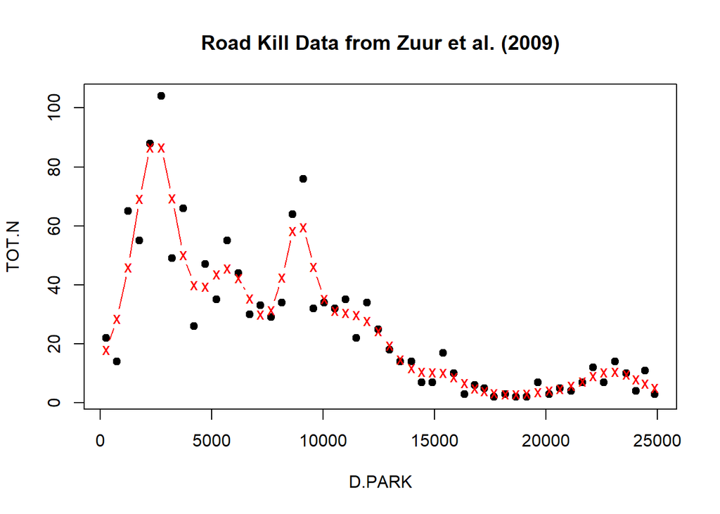

```r
{
  with(RK, plot(D.PARK, TOT.N, pch = 19, main = "Road Kill Data from Zuur et al. (2009)"))
  with(RK, points(D.PARK, fitted(fit5), pch = 'x', col = 'red', type = "b"))
}
```

```r
library(mgcv)
fit6 <- gam(TOT.N ~ s(D.PARK, k = 30), family = quasipoisson, data = RK)
summary(fit6)
```

```
##
## Family: quasipoisson
## Link function: log
##
## Formula:
## TOT.N ~ s(D.PARK, k = 30)
##
## Parametric coefficients:
##             Estimate Std. Error t value Pr(>|t|)
## (Intercept)  2.82423    0.06945   40.67   <2e-16 ***
## ---
## Signif. codes:  0 '***' 0.001 '**' 0.01 '*' 0.05 '.' 0.1 ' ' 1
##
## Approximate significance of smooth terms:
##             edf Ref.df     F p-value
## s(D.PARK) 12.97  15.96 16.19  <2e-16 ***
## ---
## Signif. codes:  0 '***' 0.001 '**' 0.01 '*' 0.05 '.' 0.1 ' ' 1
##
## R-sq.(adj) =  0.831   Deviance explained = 90.4%
## GCV =  3.693  Scale est. = 2.7065    n = 52
```

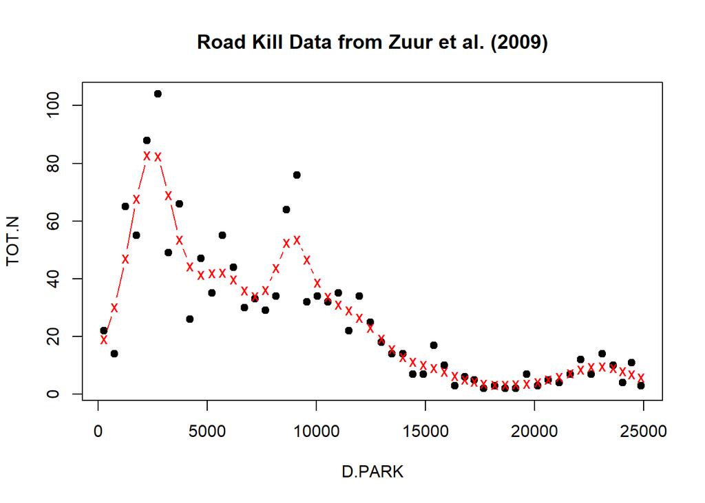

```r
{
  with(RK, plot(D.PARK, TOT.N, pch = 19, main = "Road Kill Data from Zuur et al. (2009)"))
  with(RK, points(D.PARK, fitted(fit6), pch = 'x', col = 'red', type = "b"))
}
```

Question M

The GAM suggests that the data does not follow a logarithmic model until around D.Park = 10000, in addition it showcases that there is much more variance before that point than after that point indicating that a trend or a model is only viable as a predictive model when D Park > 10000 if we are using a linear model.